# Metoda walidacji krzyżowej na danych makroekonomicznych

Wiktoria Kowalska, Emilia Lehmann, Weronika Kościug

2026-04-08

## Dane na rok 2022 dla Powiatów województwa Śląskiego i Warmińsko-mazurskiego

### Dane z Banku Danych Lokalnych GUS

Zmienne:

1.Gęstość zaludnienia (ilość ludzi na $1 km^2$) `slaskie_gest`, `warmmaz_gest`

2.Liczba ludności (pomocnicza zmienna do przeliczania wskaźników) `slaskie_ludnosc`, `warmmaz_ludnosc`

3.Liczba lokali mieszkalnych sprzedanych w ramach transakcji rynkowych `slaskie_Mieszkania`, `warmmaz_Mieszkania` (pozwolę sobie przekształcić zmienną do postaci wskaźnika na mieszkańca)

5.Przeciętne miesięczne wynagrodzenie brutto `slaskie_Wynagrodzenia`, `warmmaz_Wynagrodzenia`

## Przygotowanie i wczytanie zmiennych

Funkcja do wczytania pliku, usuniecia niepotrzebnej kolumny i zmianie nazwy jednej kolumny:

```r
przygotowanie <- function(plik, nazwa){
  ramka <- read.csv2(plik, sep=";")
  ramka <- ramka[,-4]
  names(ramka)[3] <- nazwa
  return(ramka)
}

#slaskie_gest <- przygotowanie("D:\\MRP\\Metody_Replikacyjne_Projekt\\data\\slaskieGestosc.csv","Gestosc")
#warmmaz_gest <- przygotowanie("D:\\MRP\\Metody_Replikacyjne_Projekt\\data\\warmmazGestosc.csv","Gestosc")

#slaskie_ludnosc <- przygotowanie("D:\\MRP\\Metody_Replikacyjne_Projekt\\data\\slaskieLudnosc.csv","Liczba_Ludnosci")
#warmmaz_ludnosc <- przygotowanie("D:\\MRP\\Metody_Replikacyjne_Projekt\\data\\warmmazLudnosc.csv","Liczba_Ludnosci")

#slaskie_Mieszkania <- przygotowanie("D:\\MRP\\Metody_Replikacyjne_Projekt\\data\\slaskieMieszkania.csv","Liczba_Mieszkan")
#warmmaz_Mieszkania <- przygotowanie("D:\\MRP\\Metody_Replikacyjne_Projekt\\data\\warmmazMieszkania.csv","Liczba_Mieszkan")

#slaskie_Sport <- przygotowanie("D:\\MRP\\Metody_Replikacyjne_Projekt\\data\\slaskieSport.csv","Ilosc_Obiektow")
#warmmaz_Sport <- przygotowanie("D:\\MRP\\Metody_Replikacyjne_Projekt\\data\\warmmazSport.csv","Ilosc_Obiektow")



# slaskie_Wynagrodzenia <- przygotowanie("D:\\MRP\\Metody_Replikacyjne_Projekt\\data\\slaskieWynagrodzenia.csv","Wynagrodzenia")
# warmmaz_Wynagrodzenia <- przygotowanie("D:\\MRP\\Metody_Replikacyjne_Projekt\\data\\warmmazWynagrodzenia.csv","Wynagrodzenia")

slaskie_gest <- przygotowanie("C:\\Users\\emilk\\Desktop\\MR-projekt\\Metody_Replikacyjne_Projekt\\data\\slaskieGestosc.csv","Gestosc")
warmmaz_gest <- przygotowanie("C:\\Users\\emilk\\Desktop\\MR-projekt\\Metody_Replikacyjne_Projekt\\data\\warmmazGestosc.csv","Gestosc")

slaskie_ludnosc <- przygotowanie("C:\\Users\\emilk\\Desktop\\MR-projekt\\Metody_Replikacyjne_Projekt\\data\\slaskieLudnosc.csv","Liczba_Ludnosci")
warmmaz_ludnosc <- przygotowanie("C:\\Users\\emilk\\Desktop\\MR-projekt\\Metody_Replikacyjne_Projekt\\data\\warmmazLudnosc.csv","Liczba_Ludnosci")

slaskie_Mieszkania <- przygotowanie("C:\\Users\\emilk\\Desktop\\MR-projekt\\Metody_Replikacyjne_Projekt\\data\\slaskieMieszkania.csv","Liczba_Mieszkan")
warmmaz_Mieszkania <- przygotowanie("C:\\Users\\emilk\\Desktop\\MR-projekt\\Metody_Replikacyjne_Projekt\\data\\warmmazMieszkania.csv","Liczba_Mieszkan")

slaskie_Sport <- przygotowanie("C:\\Users\\emilk\\Desktop\\MR-projekt\\Metody_Replikacyjne_Projekt\\data\\slaskieSport.csv","Ilosc_Obiektow")
warmmaz_Sport <- przygotowanie("C:\\Users\\emilk\\Desktop\\MR-projekt\\Metody_Replikacyjne_Projekt\\data\\warmmazSport.csv","Ilosc_Obiektow")

slaskie_Wynagrodzenia <- przygotowanie("C:\\Users\\emilk\\Desktop\\MR-projekt\\Metody_Replikacyjne_Projekt\\data\\slaskieWynagrodzenia.csv","Wynagrodzenia")
warmmaz_Wynagrodzenia <- przygotowanie("C:\\Users\\emilk\\Desktop\\MR-projekt\\Metody_Replikacyjne_Projekt\\data\\warmmazWynagrodzenia.csv","Wynagrodzenia")
```

Przeliczenie na wskaźniki na 10 000 mieszkańców:

```r
slaskie_Mieszkania$Liczba_Mieszkan <- slaskie_Mieszkania$Liczba_Mieszkan / slaskie_ludnosc$Liczba_Ludnosci * 10000
warmmaz_Mieszkania$Liczba_Mieszkan <- warmmaz_Mieszkania$Liczba_Mieszkan / warmmaz_ludnosc$Liczba_Ludnosci * 10000
```

## Testy permutacyjne

### Dla wariancji

```r
set.seed(999)

test_perm_var <- function(x,y){
  z <- c(x,y)
  n1 <- length(x)
  n2 <- length(y)

  s <- var(x)/var(y)
  if(s<1) s = 1/s

  smp <- sapply(1:10000, sample, x=z, size=n1+n2)

  stat <- vector()
  for(i in 1:10000){
    a <- smp[1:n1,i]
    b <- smp[(n1+1):(n1+n2),i]
    if(var(a)>var(b)){
      stat[i] <- var(a)/var(b)
    } else{
      stat[i] <- var(b)/var(a)
    }
  }
  return(sum(stat>s)/10000)
}
```

### Dla wartości oczekiwanych, skośności i kurtozy

```r
library(moments)
test_perm <- function(x,y,s){
  z <- c(x,y)
  n1 <- length(x)
  n2 <- length(y)
  m <- abs((s(x) - s(y)))

  smp <- sapply(1:10000, sample, x=z, size = n1+n2)

  stat <- vector()
  for(i in 1:10000){
    a <- smp[1:n1,i]
    b <- smp[(n1+1):(n1+n2),i]

    stat[i] <- abs(s(a)-s(b))
  }

  return(sum(stat > m)/10000)
}
```

### Wyniki testów permutacyjnych

```r
wyniki_perm <- data.frame(
  Zmienna = c("Gęstość zaludnienia","Mieszkania","Obiekty sportowe","Wynagrodzenia"),
  Średnia = c(
    test_perm(slaskie_gest$Gestosc,warmmaz_gest$Gestosc,mean),
    test_perm(slaskie_Mieszkania$Liczba_Mieszkan,warmmaz_Mieszkania$Liczba_Mieszkan,mean),
    test_perm(slaskie_Sport$Ilosc_Obiektow,warmmaz_Sport$Ilosc_Obiektow,mean),
    test_perm(slaskie_Wynagrodzenia$Wynagrodzenia,warmmaz_Wynagrodzenia$Wynagrodzenia,mean)
  ),
  Wariancja = c(
    test_perm_var(slaskie_gest$Gestosc,warmmaz_gest$Gestosc),
    test_perm_var(slaskie_Mieszkania$Liczba_Mieszkan,warmmaz_Mieszkania$Liczba_Mieszkan),
    test_perm_var(slaskie_Sport$Ilosc_Obiektow,warmmaz_Sport$Ilosc_Obiektow),
    test_perm_var(slaskie_Wynagrodzenia$Wynagrodzenia,warmmaz_Wynagrodzenia$Wynagrodzenia)
  ),
  Skośność = c(
    test_perm(slaskie_gest$Gestosc,warmmaz_gest$Gestosc,skewness),
    test_perm(slaskie_Mieszkania$Liczba_Mieszkan,warmmaz_Mieszkania$Liczba_Mieszkan,skewness),
    test_perm(slaskie_Sport$Ilosc_Obiektow,warmmaz_Sport$Ilosc_Obiektow,skewness),
    test_perm(slaskie_Wynagrodzenia$Wynagrodzenia,warmmaz_Wynagrodzenia$Wynagrodzenia,skewness)
  ),
  Kurtoza = c(
    test_perm(slaskie_gest$Gestosc,warmmaz_gest$Gestosc,kurtosis),
    test_perm(slaskie_Mieszkania$Liczba_Mieszkan,warmmaz_Mieszkania$Liczba_Mieszkan,kurtosis),
    test_perm(slaskie_Sport$Ilosc_Obiektow,warmmaz_Sport$Ilosc_Obiektow,kurtosis),
    test_perm(slaskie_Wynagrodzenia$Wynagrodzenia,warmmaz_Wynagrodzenia$Wynagrodzenia,kurtosis)
  )

)

wyniki_perm
```

```
##               Zmienna Średnia Wariancja Skośność Kurtoza
## 1 Gęstość zaludnienia  0.0009    0.0360   0.0108  0.0222
## 2          Mieszkania  0.0700    0.7829   0.2376  0.3775
## 3    Obiekty sportowe  0.3669    0.5604   0.1660  0.0621
## 4       Wynagrodzenia  0.0333    0.0285   0.0906  0.1389
```

## Testy permutacjune a testy klasyczne

Porównuję wartość wartości oczekiwanej (w tym przypadku reprezentować ją bedzie średnia) i wariancji.

```r
wyniki_klasyczne <- data.frame(
  Zmienna = c("Gęstość zaludnienia","Mieszkania","Obiekty sportowe","Wynagrodzenia"),
  Średnia_perm = wyniki_perm$Średnia,
  Średnia_klas = c(
    t.test(slaskie_gest$Gestosc,warmmaz_gest$Gestosc)$p.value,
    t.test(slaskie_Mieszkania$Liczba_Mieszkan,warmmaz_Mieszkania$Liczba_Mieszkan)$p.value,
    t.test(slaskie_Sport$Ilosc_Obiektow,warmmaz_Sport$Ilosc_Obiektow)$p.value,
    t.test(slaskie_Wynagrodzenia$Wynagrodzenia,warmmaz_Wynagrodzenia$Wynagrodzenia)$p.value
  ),
  Wariancja_perm = wyniki_perm$Wariancja,
  Wariancja_klas = c(
    var.test(slaskie_gest$Gestosc,warmmaz_gest$Gestosc)$p.value,
    var.test(slaskie_Mieszkania$Liczba_Mieszkan,warmmaz_Mieszkania$Liczba_Mieszkan)$p.value,
    var.test(slaskie_Sport$Ilosc_Obiektow,warmmaz_Sport$Ilosc_Obiektow)$p.value,
    var.test(slaskie_Wynagrodzenia$Wynagrodzenia,warmmaz_Wynagrodzenia$Wynagrodzenia)$p.value
  )
)

wyniki_klasyczne
```

```
##               Zmienna Średnia_perm Średnia_klas Wariancja_perm Wariancja_klas
## 1 Gęstość zaludnienia       0.0009 0.0001178037         0.0360   6.766177e-03
## 2          Mieszkania       0.0700 0.0797860550         0.7829   7.248701e-01
## 3    Obiekty sportowe       0.3669 0.3868982369         0.5604   5.046530e-01
## 4       Wynagrodzenia       0.0333 0.0078880485         0.0285   7.441889e-07
```

## Wybieramy zmienne objaśniające i zmienną objaśnianą

Tworzę ramkę danych, potrzebną mi do macierzy korelacji. Robie to osobno dla obu województw. Wracam również do “surowej” liczby mieszkań, bez przeliczania na 10 000 mieszkańców.

```r
slaskie <- data.frame(
  Gęstość = slaskie_gest$Gestosc,
  Ludność = slaskie_ludnosc$Liczba_Ludnosci,
  Mieszkania = ((slaskie_Mieszkania$Liczba_Mieszkan/10000)*slaskie_ludnosc$Liczba_Ludnosci),
  Sport = slaskie_Sport$Ilosc_Obiektow,
  Wynagrodzenia = slaskie_Wynagrodzenia$Wynagrodzenia
)

warmmaz <- data.frame(
  Gęstość = warmmaz_gest$Gestosc,
  Ludność = warmmaz_ludnosc$Liczba_Ludnosci,
  Mieszkania = ((warmmaz_Mieszkania$Liczba_Mieszkan/10000)*warmmaz_ludnosc$Liczba_Ludnosci),
  Sport = warmmaz_Sport$Ilosc_Obiektow,
  Wynagrodzenia = warmmaz_Wynagrodzenia$Wynagrodzenia
)
```

### Macierze korelacji

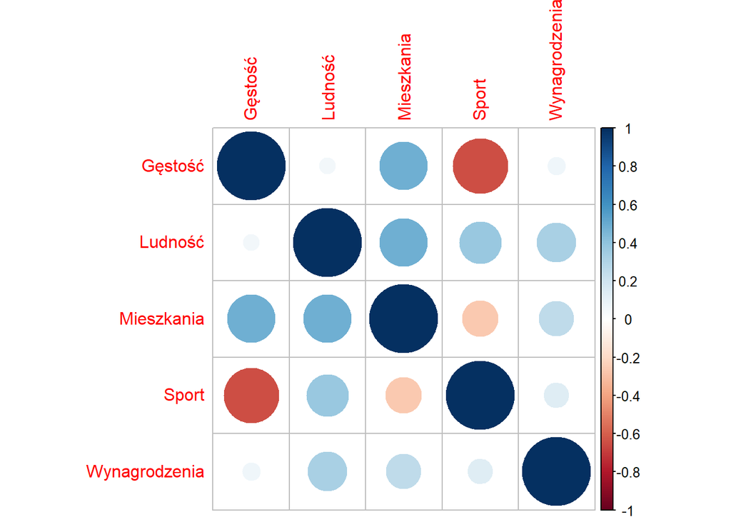

```r
library(corrplot)
corrplot(cor(slaskie))
```

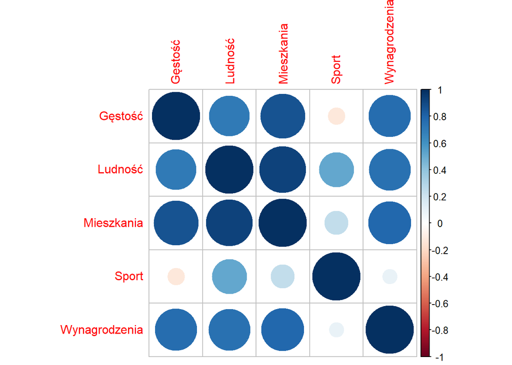

```r
corrplot(cor(warmmaz))
```

Dla województwa Śląskiego:

- zmienne objaśniające: Gęstość, Ludność, Mieszkania
- zmianna objaśniana: Sport

Dla województwa Warmińsko - Mazurskiego:

- zmienne objaśniające: Sport, Wynagrodzenia
- zmienna objaśniana: Ludność

## Metoda k-fold dla województwa Śląskiego i sprawdzenie jakości prognozy

k=9 (36 powiatów, więc po 4 w jednej grupie)

```r
library(dplyr)

errors_slaskie <- data.frame(MAE=NULL, RMSE=NULL, MAPE=NULL)
e <- vector()
n <- nrow(slaskie)
slaskie$k = rep(1:9, each= 4)[1:n]

for(i in 1:9){
  test  <- slaskie[slaskie$k == i,]
  train <- slaskie[slaskie$k != i,]

  model <- lm(Sport ~ Gęstość + Ludność + Mieszkania, train)
  p <- predict(model,test)

  e <- test$Sport - p

  df <- data.frame(
    MAE  = mean(abs(e)),
    RMSE = sqrt(mean(e^2)),
    MAPE = mean(abs(e/test$Sport)) * 100
  )

  errors_slaskie <- rbind(errors_slaskie, df)

}

errors_slaskie
```

```
##        MAE     RMSE      MAPE
## 1 32.84660 35.38958  22.92110
## 2 18.49215 23.27895  15.54401
## 3 17.68144 20.11840  23.27914
## 4 21.50809 27.22012  16.03264
## 5 21.84886 24.37899  54.25215
## 6 24.35074 31.31344  47.73184
## 7 34.49184 38.53629  70.96699
## 8 24.08832 25.35634  50.82187
## 9 39.26444 40.67753 183.75592
```

Jak widzimy model dla województwa Śląskiego najlepiej prognozuję dla foldów od 2 do 4. Dla tak wyznaczonych zbiorów testowych i treningowych myli się o około 20 obiektów sportowych, co patrząc na MAPE nie jest złym wynikiem. Dobra jakość prognozy nie występuje, jednak dla każdego foldu. Fold 9 np. ma błąd MAPE sięgający prawie 200%. Biorąc pod uwagę rozpiętość naszych danych (od 12 do 163) model radzi sobie dobrze przy większych wartościach, czego nie można powiedzieć, jeśli skupiamy się na tych mniejszych.

```r
wyniki_error_slaskie <- data.frame(
  Zmienna = c("MAE","RMSE","MAPE"),
  Średnia = c(
    mean(errors_slaskie$MAE),
    mean(errors_slaskie$RMSE),
    mean(errors_slaskie$MAPE)),
  Odchylenie_standardowe = c(
    sd(errors_slaskie$MAE),
    sd(errors_slaskie$RMSE),
    sd(errors_slaskie$MAPE)
  ),
  Min = c(
    min(errors_slaskie$MAE),
    min(errors_slaskie$RMSE),
    min(errors_slaskie$MAPE)
  ),
  Max = c(
    max(errors_slaskie$MAE),
    max(errors_slaskie$RMSE),
    max(errors_slaskie$MAPE)
  )
)

wyniki_error_slaskie
```

```
##   Zmienna  Średnia Odchylenie_standardowe      Min       Max
## 1     MAE 26.06361               7.617793 17.68144  39.26444
## 2    RMSE 29.58551               7.244050 20.11840  40.67753
## 3    MAPE 53.92285              52.445125 15.54401 183.75592
```

Z powyższych statystyk wynika, że błędy są rozłożone dość równomiernie, brak outlinerów (wnioskujemy z tego, że średnie MAE i RMSE nie odbiegają znacznie od siebie). Największą wartość ma współczynnik MAPE (przeszło 50%) zarówno, jeśli chodzi o jego średnią jak i odchylenie standardowe. Potwierdza to stwierdzenie, że model prognozuje lepiej dla wyzszych wartość.

## Metoda k-fold dla województwa Warmińsko-Mazurskiego i sprawdzenie jakości prognozy

k=7 (21 powiatów, więc po 3 w jednej grupie)

```r
errors_warmmaz <- data.frame(MAE=NULL, RMSE=NULL, MAPE=NULL)
e1 <- vector()
n1 <- nrow(warmmaz)
warmmaz$k = rep(1:7, each= 3)[1:n1]

for(i in 1:7){
  test  <- warmmaz[warmmaz$k == i,]
  train <- warmmaz[warmmaz$k != i,]

  model <- lm( Ludność ~ Wynagrodzenia + Sport , train)
  p <- predict(model,test)

  e1 <- test$Ludność - p

  df <- data.frame(
    MAE  = mean(abs(e1)),
    RMSE = sqrt(mean(e1^2)),
    MAPE = mean(abs(e1/test$Ludność)) * 100
  )

  errors_warmmaz <- rbind(errors_warmmaz, df)

}

errors_warmmaz
```

```
##        MAE      RMSE     MAPE
## 1 14500.84 17547.705 33.32838
## 2 16874.56 20059.836 24.07162
## 3  7416.92  8197.284 13.02176
## 4 25648.04 32115.858 67.21706
## 5 17409.27 18931.289 34.11975
## 6 11052.76 14729.719 20.95349
## 7 54357.28 61248.819 62.43124
```

Dla województwa Warmińsko - Mazurskiego najskuteczniejszą prognozę daję nam fold 3 z jedynie 13% błędem. MAPE jest, jednak znów zróżnicowany dla poszczególnych foldów. Waha się od prognozy bardzo dobrej (13%) do niedokładnej (67%). Po raz kolejny może mieć to związek z rozpiętością danych.

```r
wyniki_error_warmmaz <- data.frame(
  Zmienna = c("MAE","RMSE","MAPE"),
  Średnia = c(
    mean(errors_warmmaz$MAE),
    mean(errors_warmmaz$RMSE),
    mean(errors_warmmaz$MAPE)),
  Odchylenie_standardowe = c(
    sd(errors_warmmaz$MAE),
    sd(errors_warmmaz$RMSE),
    sd(errors_warmmaz$MAPE)
  ),
  Min = c(
    min(errors_warmmaz$MAE),
    min(errors_warmmaz$RMSE),
    min(errors_warmmaz$MAPE)
  ),
  Max = c(
    max(errors_warmmaz$MAE),
    max(errors_warmmaz$RMSE),
    max(errors_warmmaz$MAPE)
  )
)

wyniki_error_warmmaz
```

```
##   Zmienna     Średnia Odchylenie_standardowe        Min         Max
## 1     MAE 21037.09382            15758.07725 7416.92042 54357.27708
## 2    RMSE 24690.07299            17647.10119 8197.28407 61248.81949
## 3    MAPE    36.44904               20.73267   13.02176    67.21706
```

Tutaj również nie mamy problemu z outlinerami w błędach. Średnie MAPE wynosi 36%, co jest lepszym wynikiem w porówaniu z województwem Śląskim.